# Part I - (Prosper Loan Exploration)

## Introduction

> This data set contains 113,937 loans with 81 variables on each loan, including loan amount, borrower rate (or interest rate), current loan status, borrower income, and many others.

## Preliminary Wrangling

```python
# import all packages and set plots to be embedded inline
import numpy as np
import pandas as pd
import matplotlib.pyplot as plt
import seaborn as sb

%matplotlib inline
```

```python
# load in the dataset into a pandas dataframe, print statistics
df = pd.read_csv('prosper-loan-data.csv')
```

```python
# high-level overview of data shape and composition
pd.set_option("display.max_columns", len(df.columns))
print(df.shape)
```

```
(113937, 81)
```

```python
df.sample(6)
```

|  | ListingKey | ListingNumber | ListingCreationDate | CreditGrade | Term | LoanStatus | ClosedDate | BorrowerAPR | BorrowerRate | LenderYield | EstimatedEffectiveYield | EstimatedLoss | EstimatedReturn | ProsperRating (numeric) | ProsperRating (Alpha) | ProsperScore | ListingCategory (numeric) | BorrowerState | Occupation | EmploymentStatus | EmploymentStatusDuration | IsBorrowerHomeowner | CurrentlyInGroup | GroupKey | DateCreditPulled | CreditScoreRangeLower | CreditScoreRangeUpper | FirstRecordedCreditLine | CurrentCreditLines | … |
| --- | --- | --- | --- | --- | --- | --- | --- | --- | --- | --- | --- | --- | --- | --- | --- | --- | --- | --- | --- | --- | --- | --- | --- | --- | --- | --- | --- | --- | --- | --- |
| 49658 | 4AAD3375245869453C54D1F | 74878 | 2006-12-14 21:37:22.453000000 | B | 36 | Completed | 2008-01-30 00:00:00 | 0.11129 | 0.0997 | 0.0947 | NaN | NaN | NaN | NaN | NaN | NaN | 0 | CO | Professional | Not available | NaN | False | False | NaN | 2006-12-14 21:29:00.073000000 | 680.0 | 699.0 | 2002-09-30 00:00:00 | NaN | … |
| 27185 | 6A93357078952274188993E | 713366 | 2013-02-16 06:21:09.430000000 | NaN | 60 | Current | NaN | 0.29341 | 0.2672 | 0.2572 | 0.23550 | 0.1125 | 0.12300 | 3.0 | D | 7.0 | 1 | NY | Professional | Employed | 89.0 | False | False | NaN | 2013-04-05 12:28:09 | 660.0 | 679.0 | 2000-09-01 00:00:00 | 28.0 | … |
| 113499 | E2A13536242745521CD3B78 | 553394 | 2012-01-22 10:39:34.467000000 | NaN | 36 | Current | NaN | 0.23990 | 0.2024 | 0.1924 | 0.18790 | 0.0850 | 0.10290 | 4.0 | C | 4.0 | 1 | MD | Computer Programmer | Employed | 197.0 | True | False | NaN | 2012-01-22 10:39:30 | 680.0 | 699.0 | 1989-11-07 00:00:00 | 23.0 | … |
| 2608 | 04353599711883060BEC539 | 1142619 | 2014-01-15 20:18:04.330000000 | NaN | 36 | Current | NaN | 0.09030 | 0.0769 | 0.0669 | 0.06546 | 0.0174 | 0.04806 | 7.0 | AA | 9.0 | 1 | KS | Professional | Employed | 161.0 | True | False | NaN | 2014-01-15 20:18:06 | 720.0 | 739.0 | 1992-04-16 00:00:00 | 13.0 | … |
| 3718 | 75193546991125604FE55B6 | 587793 | 2012-05-10 18:10:05.413000000 | NaN | 36 | Current | NaN | 0.25259 | 0.2148 | 0.2048 | 0.20000 | 0.0890 | 0.11100 | 4.0 | C | 6.0 | 1 | MA | Other | Employed | 32.0 | True | False | NaN | 2012-05-10 18:10:01 | 740.0 | 759.0 | 1993-05-01 00:00:00 | 4.0 | … |
| 9899 | 0CBB3599452902927C4C8A9 | 1082635 | 2014-01-03 17:49:38.133000000 | NaN | 60 | Current | NaN | 0.12614 | 0.1039 | 0.0939 | 0.09071 | 0.0299 | 0.06081 | 6.0 | A | 10.0 | 1 | WV | Attorney | Employed | 89.0 | False | False | NaN | 2014-01-03 17:49:40 | 700.0 | 719.0 | 1974-09-01 00:00:00 | 9.0 | … |

```python
loans = df.loc[:, ['Term', 'BorrowerAPR', 'IncomeRange', 'StatedMonthlyIncome',
                   'IncomeVerifiable', 'IsBorrowerHomeowner', 'LoanOriginalAmount',
                   'LoanOriginationQuarter', 'EstimatedReturn', 'ProsperRating (numeric)',
                   'ProsperScore']]
```

```python
loans.shape
```

```
(113937, 11)
```

```python
loans.sample(7)
```

|  | Term | BorrowerAPR | IncomeRange | StatedMonthlyIncome | IncomeVerifiable | IsBorrowerHomeowner | LoanOriginalAmount | LoanOriginationQuarter | EstimatedReturn | ProsperRating (numeric) | ProsperScore |
| --- | --- | --- | --- | --- | --- | --- | --- | --- | --- | --- | --- |
| 48250 | 60 | 0.35838 | $25,000-49,999 | 3666.666667 | True | False | 4000 | Q2 2012 | 0.1587 | 2.0 | 6.0 |
| 4393 | 36 | 0.37453 | $1-24,999 | 1993.333333 | True | False | 5600 | Q1 2010 | 0.1843 | 2.0 | 6.0 |
| 46051 | 36 | 0.41355 | $100,000+ | 9166.666667 | True | False | 1000 | Q4 2008 | NaN | NaN | NaN |
| 20862 | 60 | 0.28386 | $75,000-99,999 | 7333.333333 | True | True | 15000 | Q3 2013 | 0.1199 | 3.0 | 2.0 |
| 43438 | 36 | 0.11194 | Not displayed | 5666.666667 | True | False | 15000 | Q1 2007 | NaN | NaN | NaN |
| 27308 | 36 | 0.27467 | $25,000-49,999 | 3750.000000 | True | True | 3500 | Q2 2011 | 0.1243 | 3.0 | 4.0 |
| 17414 | 60 | 0.16499 | $100,000+ | 11333.333333 | True | True | 15000 | Q2 2013 | 0.0836 | 5.0 | 6.0 |

```python
loans.info()
```

```
<class 'pandas.core.frame.DataFrame'>
RangeIndex: 113937 entries, 0 to 113936
Data columns (total 11 columns):
 #   Column                   Non-Null Count   Dtype
---  ------                   --------------   -----
 0   Term                     113937 non-null  int64
 1   BorrowerAPR              113912 non-null  float64
 2   IncomeRange              113937 non-null  object
 3   StatedMonthlyIncome      113937 non-null  float64
 4   IncomeVerifiable         113937 non-null  bool
 5   IsBorrowerHomeowner      113937 non-null  bool
 6   LoanOriginalAmount       113937 non-null  int64
 7   LoanOriginationQuarter   113937 non-null  object
 8   EstimatedReturn          84853 non-null   float64
 9   ProsperRating (numeric)  84853 non-null   float64
 10  ProsperScore             84853 non-null   float64
dtypes: bool(2), float64(5), int64(2), object(2)
memory usage: 8.0+ MB
```

```python
loans.isnull().sum()
```

```
Term                           0
BorrowerAPR                   25
IncomeRange                    0
StatedMonthlyIncome            0
IncomeVerifiable               0
IsBorrowerHomeowner            0
LoanOriginalAmount             0
LoanOriginationQuarter         0
EstimatedReturn            29084
ProsperRating (numeric)    29084
ProsperScore               29084
dtype: int64
```

```python
loans = loans.dropna()
```

```python
loans.isnull().sum()
```

```
Term                       0
BorrowerAPR                0
IncomeRange                0
StatedMonthlyIncome        0
IncomeVerifiable           0
IsBorrowerHomeowner        0
LoanOriginalAmount         0
LoanOriginationQuarter     0
EstimatedReturn            0
ProsperRating (numeric)    0
ProsperScore               0
dtype: int64
```

```python
loans[['OriginationQuarter', 'OriginationYear']] = loans.LoanOriginationQuarter.str.split(" ", expand=True)

loans.drop(columns=['LoanOriginationQuarter', 'OriginationYear'], inplace=True)
```

```python
loans
```

|  | Term | BorrowerAPR | IncomeRange | StatedMonthlyIncome | IncomeVerifiable | IsBorrowerHomeowner | LoanOriginalAmount | EstimatedReturn | ProsperRating (numeric) | ProsperScore | OriginationQuarter |
| --- | --- | --- | --- | --- | --- | --- | --- | --- | --- | --- | --- |
| 1 | 36 | 0.12016 | $50,000-74,999 | 6125.000000 | True | False | 10000 | 0.05470 | 6.0 | 7.0 | Q1 |
| 3 | 36 | 0.12528 | $25,000-49,999 | 2875.000000 | True | True | 10000 | 0.06000 | 6.0 | 9.0 | Q4 |
| 4 | 36 | 0.24614 | $100,000+ | 9583.333333 | True | True | 15000 | 0.09066 | 3.0 | 4.0 | Q3 |
| 5 | 60 | 0.15425 | $100,000+ | 8333.333333 | True | True | 15000 | 0.07077 | 5.0 | 10.0 | Q4 |
| 6 | 36 | 0.31032 | $25,000-49,999 | 2083.333333 | True | False | 3000 | 0.11070 | 2.0 | 2.0 | Q2 |
| ... | ... | ... | ... | ... | ... | ... | ... | ... | ... | ... | ... |
| 113932 | 36 | 0.22354 | $50,000-74,999 | 4333.333333 | True | True | 10000 | 0.09500 | 4.0 | 5.0 | Q2 |
| 113933 | 36 | 0.13220 | $75,000-99,999 | 8041.666667 | True | True | 2000 | 0.08070 | 6.0 | 8.0 | Q4 |
| 113934 | 60 | 0.23984 | $25,000-49,999 | 2875.000000 | True | True | 10000 | 0.08578 | 3.0 | 3.0 | Q4 |
| 113935 | 60 | 0.28408 | $25,000-49,999 | 3875.000000 | True | True | 15000 | 0.15950 | 4.0 | 5.0 | Q4 |
| 113936 | 36 | 0.13189 | $50,000-74,999 | 4583.333333 | True | False | 2000 | 0.06081 | 6.0 | 7.0 | Q1 |

84853 rows × 11 columns

```python
# Convert IncomeRange to ordinal categorical
ordinal_var_dict = {'IncomeRange':['$0','$1-24,999','$25,000-49,999','$50,000-74,999','$75,000-99,999','$100,000+']}

for var in ordinal_var_dict:
    ordered_var = pd.api.types.CategoricalDtype(ordered = True, categories = ordinal_var_dict[var])
    loans[var] = loans[var].astype(ordered_var)
```

```python
loans['StatedMonthlyIncome'] = loans.StatedMonthlyIncome.round(2)
```

```python
loans.info()
```

```
<class 'pandas.core.frame.DataFrame'>
Int64Index: 84853 entries, 1 to 113936
Data columns (total 11 columns):
 #   Column                   Non-Null Count  Dtype
---  ------                   --------------  -----
 0   Term                     84853 non-null  int64
 1   BorrowerAPR              84853 non-null  float64
 2   IncomeRange              84204 non-null  category
 3   StatedMonthlyIncome      84853 non-null  float64
 4   IncomeVerifiable         84853 non-null  bool
 5   IsBorrowerHomeowner      84853 non-null  bool
 6   LoanOriginalAmount       84853 non-null  int64
 7   EstimatedReturn          84853 non-null  float64
 8   ProsperRating (numeric)  84853 non-null  float64
 9   ProsperScore             84853 non-null  float64
 10  OriginationQuarter       84853 non-null  object
dtypes: bool(2), category(1), float64(5), int64(2), object(1)
memory usage: 6.1+ MB
```

```python
loans.IncomeRange.isnull().sum()
```

```
649
```

```python
loans.shape
```

```
(84853, 11)
```

```python
loans.describe()
```

|  | Term | BorrowerAPR | StatedMonthlyIncome | LoanOriginalAmount | EstimatedReturn | ProsperRating (numeric) | ProsperScore |
| --- | --- | --- | --- | --- | --- | --- | --- |
| count | 84853.000000 | 84853.000000 | 8.485300e+04 | 84853.000000 | 84853.000000 | 84853.000000 | 84853.000000 |
| mean | 42.486135 | 0.226658 | 5.931175e+03 | 9083.440515 | 0.096068 | 4.072243 | 5.950067 |
| std | 11.640346 | 0.079916 | 8.239944e+03 | 6287.860058 | 0.030403 | 1.673227 | 2.376501 |
| min | 12.000000 | 0.045830 | 0.000000e+00 | 1000.000000 | -0.182700 | 1.000000 | 1.000000 |
| 25% | 36.000000 | 0.163280 | 3.434000e+03 | 4000.000000 | 0.074080 | 3.000000 | 4.000000 |
| 50% | 36.000000 | 0.219450 | 5.000000e+03 | 7500.000000 | 0.091700 | 4.000000 | 6.000000 |
| 75% | 60.000000 | 0.292540 | 7.083330e+03 | 13500.000000 | 0.116600 | 5.000000 | 8.000000 |
| max | 60.000000 | 0.423950 | 1.750003e+06 | 35000.000000 | 0.283700 | 7.000000 | 11.000000 |

### What is the structure of your dataset?

> However, I will be working with just 84853 rows and 11 of those columns

### What is/are the main feature(s) of interest in your dataset?

> How does the length of the loan (Term) affect the Estimated Return?

> What time of the year are people more likely to borrow?

> Does being a homeowner affect the loan amount?

> Does having a verifiable income ensure larger loan amounts?

> How does the length of the loan (Term) affect the Borrower’s Annual Percentage Rate (APR)?

### What features in the dataset do you think will help support your investigation into your feature(s) of interest?

> In order to explore all the hypotheses put forth, I believe the features Term, Estimated Return, and Original Loan Amount will be very helpful. Also the effects of verifiable income and home ownership should faciliate larger amounts

## Univariate Exploration

### Estimated Return

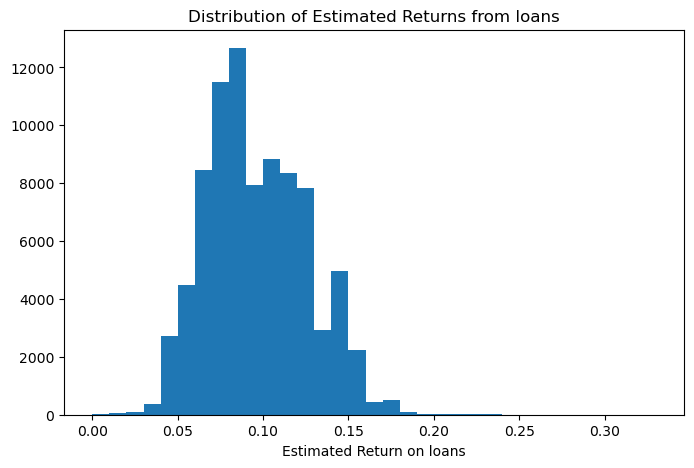

```python
plt.figure(figsize=[8, 5])
bins = np.arange(0, loans.EstimatedReturn.max()+0.05, 0.01)
plt.hist(data = loans, x = 'EstimatedReturn', bins = bins);
plt.title('Distribution of Estimated Returns from loans')
plt.xlabel('Estimated Return on loans');
```

> This shows the distribution to be multimodal. The highest peak between 0.05 and 0.10 (which is another peak) then there is a small peak around 0.15.

> This indicates that Prosper projects to averagely make 5-15% return on loans.

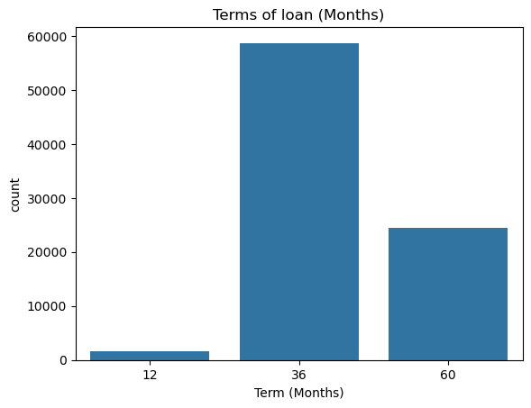

```python
base_color = sb.color_palette()[0]
sb.countplot(data=loans,x= 'Term',color=base_color);
plt.title('Terms of loan (Months)')
plt.xlabel('Term (Months)');
```

> Loan terms are either year (12 month) or 3 years (36 months) or 5 years (60 months) with most of the loans having a 3-year term

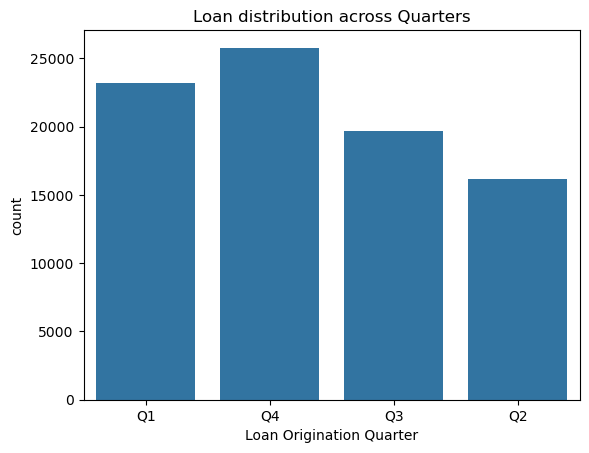

```python
# Loan Origination Quarter
base_color = sb.color_palette()[0]
sb.countplot(data=loans, x= 'OriginationQuarter', color=base_color)
plt.title('Loan distribution across Quarters')
plt.xlabel('Loan Origination Quarter');
```

> Most loans are taken in Q4 followed by Q1. That indicates that most loan are borrowed between October and March

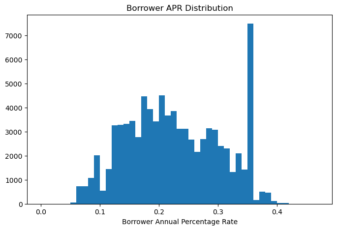

```python
plt.figure(figsize=[8, 5])
bins = np.arange(0, loans.BorrowerAPR.max()+0.05, 0.01)
plt.hist(data = loans, x = 'BorrowerAPR', bins = bins);
plt.title('Borrower APR Distribution')
plt.xlabel('Borrower Annual Percentage Rate');
```

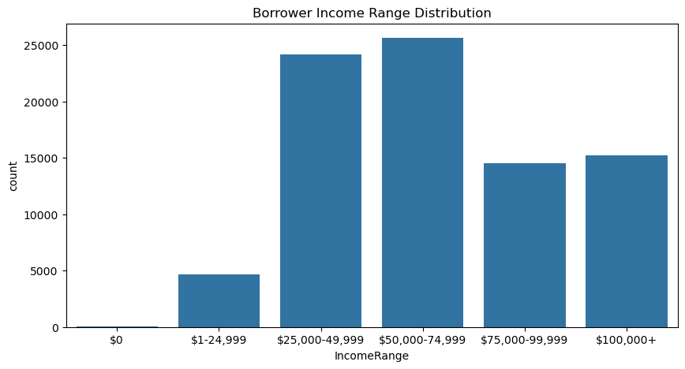

```python
#Borrower Income Range Status Distrobution
plt.figure(figsize=[10, 5])
sb.countplot(data=loans,x='IncomeRange',color=base_color);
plt.title('Borrower Income Range Distribution');
```

> > Most loans are taken by those with income range between the 50,000-74,999 followed closely by those in the 25,000-49,999 range It will be safe to say that most loans are taken by people with income between 25,000 and 74,999

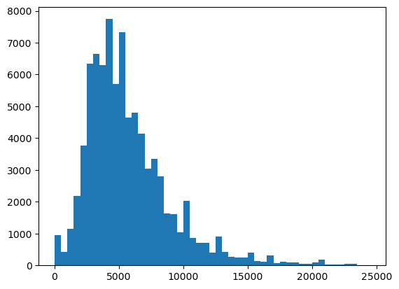

```python
# Distribution of stated monthly income
bins_smi = np.arange(0, 25000, 500)
plt.hist(data = loans, x = 'StatedMonthlyIncome', bins=bins_smi);
```

> Most monthly income is around 5000 and seldom above 20000

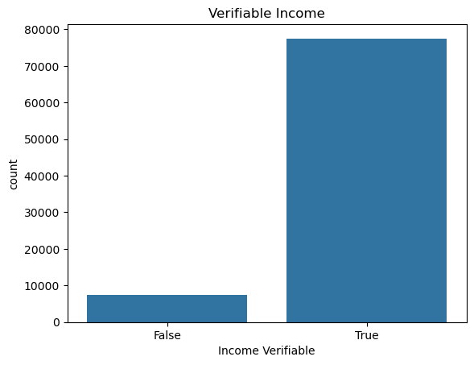

```python
base_color = sb.color_palette()[0]
sb.countplot(data=loans,x= 'IncomeVerifiable',color=base_color);
plt.title('Verifiable Income')
plt.xlabel('Income Verifiable');
```

> Majority of borrowers have verifiable income

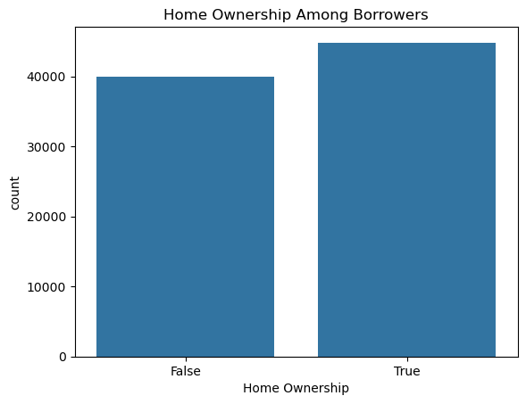

```python
base_color = sb.color_palette()[0]
sb.countplot(data=loans,x= 'IsBorrowerHomeowner',color=base_color);
plt.title('Home Ownership Among Borrowers')
plt.xlabel('Home Ownership');
```

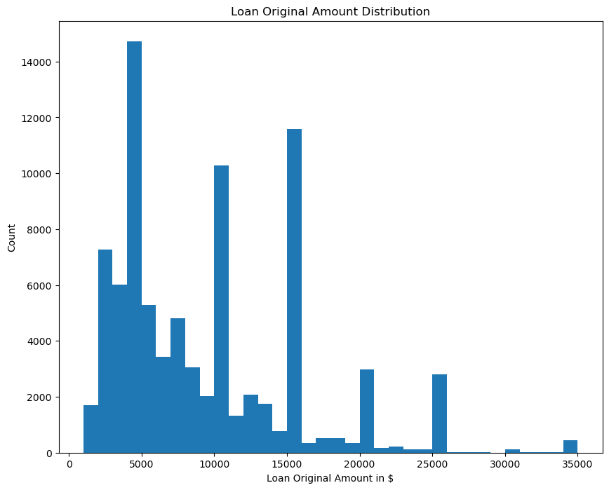

```python
# Loan Original Amount Distribution
binsize = 1000
bins = np.arange(loans['LoanOriginalAmount'].min(), loans['LoanOriginalAmount'].max()+binsize, binsize)

plt.figure(figsize=[10, 8])
plt.hist(data = loans, x = 'LoanOriginalAmount', bins = bins)
plt.title('Loan Original Amount Distribution')
plt.xlabel('Loan Original Amount in $')
plt.ylabel('Count')
plt.show()
```

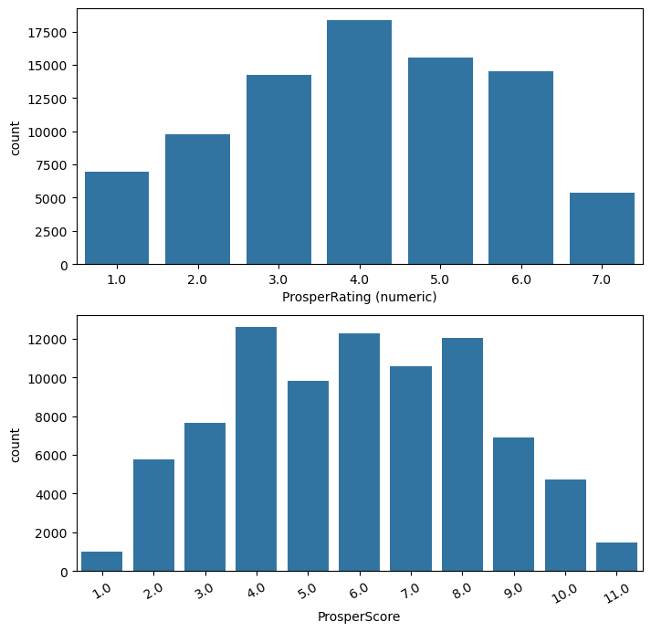

```python
fig, ax = plt.subplots(nrows=2, figsize = [8,8])
default_color = sb.color_palette()[0]
sb.countplot(data = loans, x = 'ProsperRating (numeric)', color = default_color, ax = ax[0])
sb.countplot(data = loans, x = 'ProsperScore', color = default_color, ax = ax[1]);
plt.xticks(rotation=30);
```

> Most ratings fall in between 3.0 and 6.0.

> I believe ProsperScore be understood more in relation to other variables

### Discuss the distribution(s) of your variable(s) of interest. Were there any unusual points? Did you need to perform any transformations?

> The distribution of EstimatedReturns suggests that Prosper projects making on average a 5-15% return on loans

### Of the features you investigated, were there any unusual distributions? Did you perform any operations on the data to tidy, adjust, or change the form of the data? If so, why did you do this?

> I had to separate the LoanOriginationQuarter column so as to get the raw quarter values without the year attached

## Bivariate Exploration

```python
numeric_variables = ['LoanOriginalAmount', 'Term', 'BorrowerAPR', 'EstimatedReturn', 'ProsperScore', 'ProsperRating (numeric)', 'StatedMonthlyIncome']

categorical_variables = ['IncomeRange', 'IsBorrowerHomeowner', 'OriginationQuarter']
```

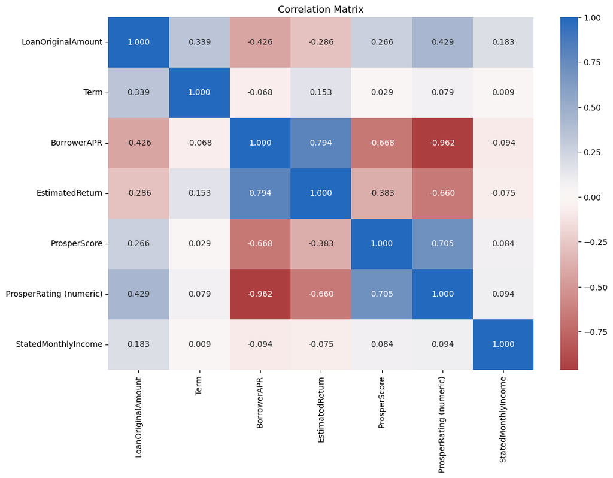

```python
# Correlation matrix for all numeric variables
plt.figure(figsize = [12, 8])
sb.heatmap(loans[numeric_variables].corr(), annot = True, fmt = '.3f', cmap = 'vlag_r', center = 0)
plt.title('Correlation Matrix')
plt.show()
```

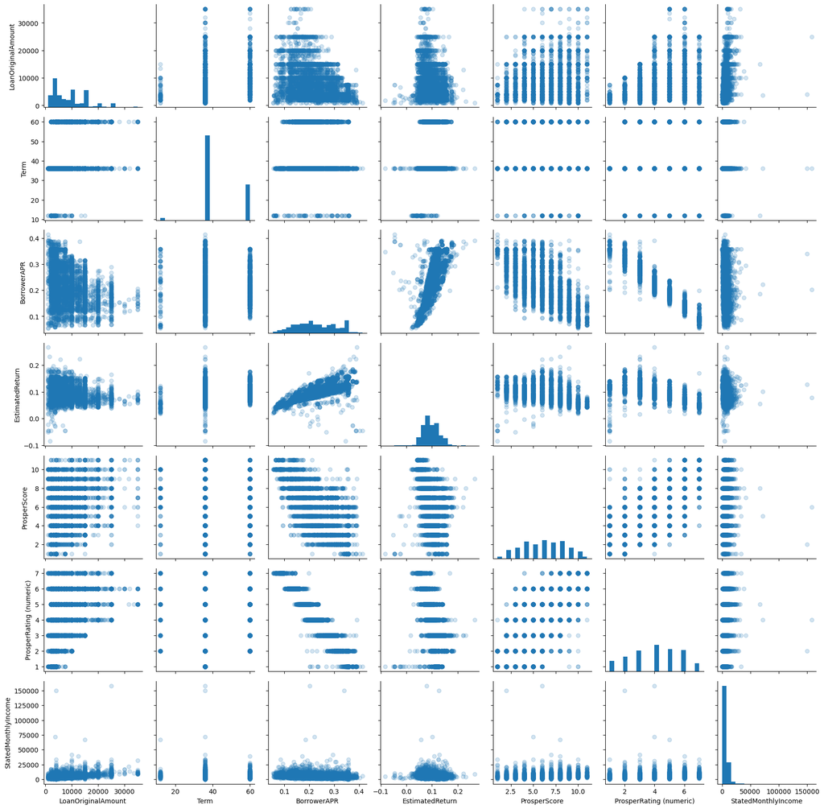

```python
# plot matrix: sample 5000 loans so that plots are clearer and render faster
loans_samp = loans.sample(5000)
g = sb.PairGrid(data = loans_samp.dropna(), vars = numeric_variables)
g = g.map_diag(plt.hist, bins=20)
g.map_offdiag(plt.scatter, alpha=0.2);
```

> High positive correlation between BorrowerAPR and Estimated Return which means the higher the APR the higher the estimated return

> The correlation coefficient of borrower APR and loan original amount is negative, which suggests that is the more the loan amount, the lower the APR.

> Estimated Return is more negatively correlated with Prosper Rating than Prosper Score

> As expected Prosper Ratings and Prosper Score are highly correlated Though it would seem that Prosper rating give a sharper and more definitive picture than Prosper Scores

> BorrowerAPR has high negative correlation with Prosper Rating and a mild negative correlation with Prosper Score

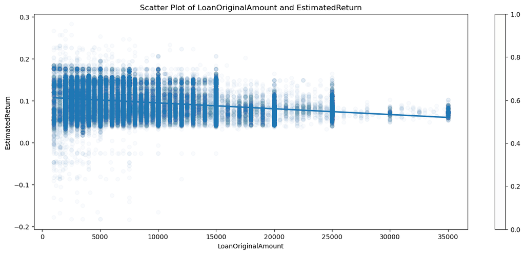

```python
# Checking the relation between LoanOriginalAmount and Estimated Return

plt.figure(figsize = [15, 6])
sb.regplot(data = loans, x = 'LoanOriginalAmount', y = 'EstimatedReturn', scatter_kws={'alpha':0.01});
plt.scatter(data = loans, x = 'LoanOriginalAmount', y = 'EstimatedReturn',  alpha =  0.01)
plt.title('Scatter Plot of LoanOriginalAmount and EstimatedReturn')
plt.xlabel('LoanOriginalAmount')
plt.ylabel('EstimatedReturn');
plt.colorbar();
```

> A negative relationship which means that larger the loan the lesser the percentage Estimated Return

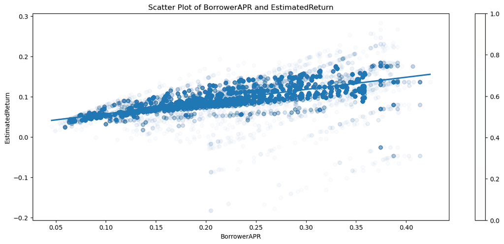

```python
# Checking the relation between Estimated Return and APR

plt.figure(figsize = [15, 6])
sb.regplot(data = loans, x = 'BorrowerAPR', y = 'EstimatedReturn', scatter_kws={'alpha':0.01});
plt.scatter(data = loans, x = 'BorrowerAPR', y = 'EstimatedReturn',  alpha =  0.01)
plt.title('Scatter Plot of BorrowerAPR and EstimatedReturn')
plt.xlabel('BorrowerAPR')
plt.ylabel('EstimatedReturn');
plt.colorbar();
```

> The higher the annual interest, the higher the estimated return

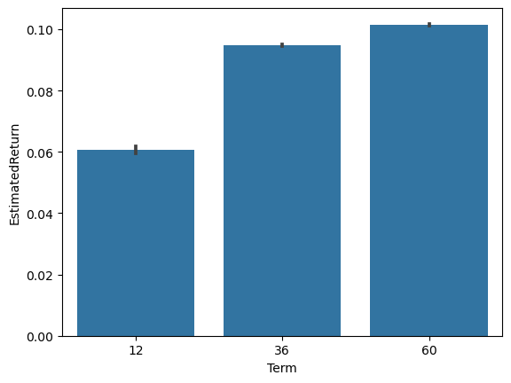

```python
sb.barplot(data=loans, x='Term', y='EstimatedReturn', color=base_color)
```

> This clearly shows that the longer the loan term the higher the estimated returns

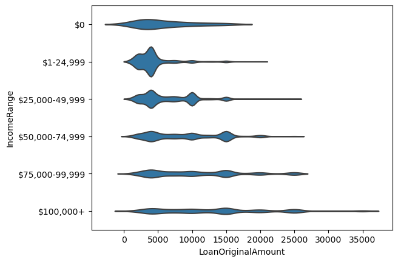

```python
#Income range vs Loan amount

sb.violinplot(data=loans, y='IncomeRange', x='LoanOriginalAmount', color=base_color, inner=None);
```

> Most amount of loans are taken by earners in the 1-74,999 range and is generally around 5-10k

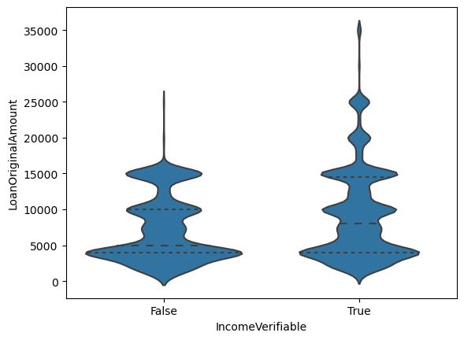

```python
sb.violinplot(data=loans, x='IncomeVerifiable', y='LoanOriginalAmount', color=base_color, inner='quartile');
```

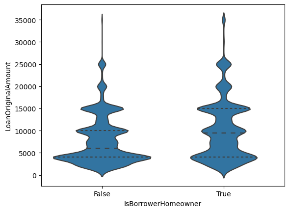

```python
sb.violinplot(data=loans, x='IsBorrowerHomeowner', y='LoanOriginalAmount', color=base_color, inner='quartile');
```

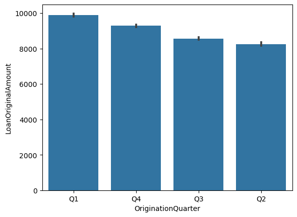

```python
sb.barplot(data=loans, x='OriginationQuarter', y='LoanOriginalAmount', color=base_color)
```

### Talk about some of the relationships you observed in this part of the investigation. How did the feature(s) of interest vary with other features in the dataset?

> A negative relationship between loan amount and the estimated percentage return which means that larger the loan the lesser the percentage Estimated Return

> High positive correlation between BorrowerAPR and Estimated Return which means the higher the APR the higher the estimated return

> Most amount of loans are taken by earners in the 1-74,999 range and is generally around 5-10k

### Did you observe any interesting relationships between the other features (not the main feature(s) of interest)?

> As expected Prosper Ratings and Prosper Score are highly correlated It would seem that Prosper rating give a sharper and more definitive picture than Prosper Scores

## Multivariate Exploration

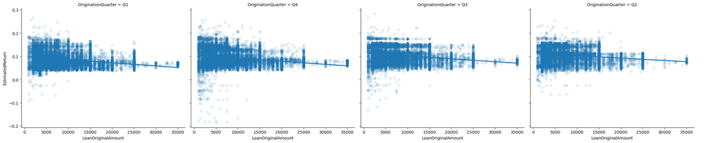

```python
# Seasonal effect on relationship of Estimated Return and loan amount
g=sb.FacetGrid(data=loans, aspect=1.2, height=5, col='OriginationQuarter', col_wrap=4)
g.map(sb.regplot, 'LoanOriginalAmount', 'EstimatedReturn', x_jitter=0.04, scatter_kws={'alpha':0.1});
g.add_legend();
```

> Seems there are no seasonal effects on the Estimated Return or the Loan Amount

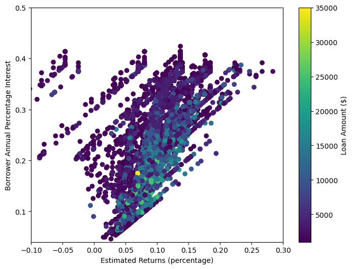

```python
# Estimated return vs APR vs Loan Amount

plt.figure(figsize = [8,6])
plt.scatter(data = loans, x = 'EstimatedReturn', y = 'BorrowerAPR',c = 'LoanOriginalAmount')
plt.colorbar(label = 'Loan Amount ($)')
plt.xlim(-0.1,0.3)
plt.ylim(0.04,0.5)
plt.xlabel('Estimated Returns (percentage)')
plt.ylabel('Borrower Annual Percentage Interest')
```

> Larger loans have lesser APRs while the estimated returns are roughly around 5-15% range. lesser loan amounts have higher APRs and largely within 0-25% range

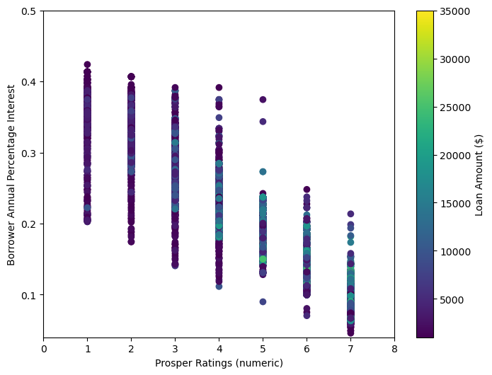

```python
plt.figure(figsize = [8,6])
plt.scatter(data = loans, x = 'ProsperRating (numeric)', y = 'BorrowerAPR',c = 'LoanOriginalAmount')
plt.colorbar(label = 'Loan Amount ($)')
plt.xlim(0.0,8.0)
plt.ylim(0.04,0.5)
plt.xlabel('Prosper Ratings (numeric)')
plt.ylabel('Borrower Annual Percentage Interest')
```

> APR decreases with better ratings while Loan amount increases with better ratings

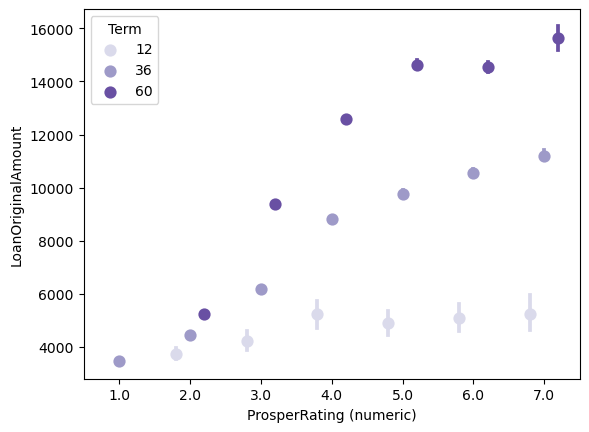

```python
sb.pointplot(data = loans, x = 'ProsperRating (numeric)', y = 'LoanOriginalAmount', hue = 'Term',
           palette = 'Purples', linestyles = '', dodge = 0.4);
```

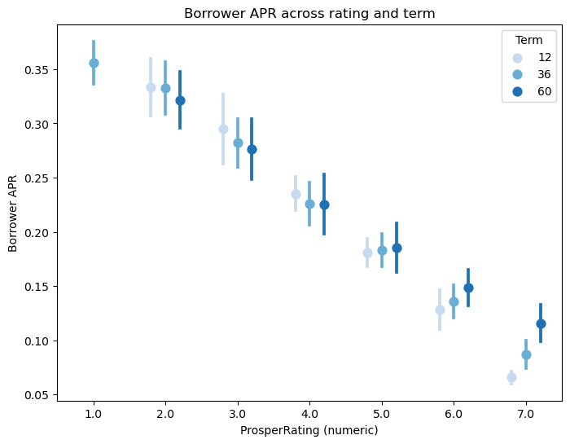

```python
fig = plt.figure(figsize = [8,6])
ax = sb.pointplot(data = loans, x = 'ProsperRating (numeric)', y = 'BorrowerAPR', hue = 'Term',
           palette = 'Blues', linestyles = '', dodge = 0.4, ci='sd')
plt.title('Borrower APR across rating and term')
plt.ylabel('Borrower APR')
ax.set_yticklabels([],minor = True);
```

> The borrower APR generally decrease with the increase of borrow term for people with 1.0-4.0 ratings. But for people with 5.0-7.0 ratings, the APR actually increases with the borrow term

### Talk about some of the relationships you observed in this part of the investigation. Were there features that strengthened each other in terms of looking at your feature(s) of interest?

> Larger loans have lesser APRs while the estimated returns are roughly around 5-15% range. lesser loan amounts have higher APRs and largely within 0-25% range

> Borrower APR decreases with better ratings while Loan amount increases with better ratings

### Were there any interesting or surprising interactions between features?

> The borrower APR generally decrease with the increase of borrow term for people with 1.0-4.0 ratings. But for people with 5.0-7.0 ratings, the APR actually increases with the borrow term